# Introduction

Data about bails sourced from the [city of Philadelphia](https://opendataphilly.org/datasets/). This is a data set that includes information about what bails were set and for what crime over the entire city of Philadelphia from 2014 to 2022. Data about daily weather in Philadelphia (specifically measured at the Philadelphia Airport) sourced from [National Centers for Environmental Information](https://www.ncei.noaa.gov/). The [formal documentation](https://www.ncei.noaa.gov/pub/data/cdo/documentation/GHCND_documentation.pdf) lists out what each column in the weather dataset means, so I'll leave the column names as they are to not stray from the documentation.

```python
import pandas as pd
import seaborn as sns
import numpy as np
import matplotlib.pyplot as plt
bails = pd.read_csv('bail_data_daily_citywide.txt')
weather = pd.read_csv('daily_weather_data.csv')
```

# Preprocessing

the preprocessing is relatively straight forward. There are no missing values for bails, and for weather I just want to remove the annoying and useless 'station' and 'name' columns.

```python
weather = weather.drop(columns=["STATION","NAME"])
bails.head(5)
```

|  | date_value | bail_category | Aggravated Assault | Altered Firearm Serial Number | Arson | Attempted Murder | Auto Theft | Burglary/Commercial | Burglary/Residential | Carjacking | ... | Sexual Assault and Other Sex Offenses | Simple Assault | Strangulation | Theft | Theft from Auto | Threats of Violence | Trespass | Uncategorized Offenses | Victim/Witness Intimidation & Retaliation | Violation of Protection Order |
| --- | --- | --- | --- | --- | --- | --- | --- | --- | --- | --- | --- | --- | --- | --- | --- | --- | --- | --- | --- | --- | --- |
| 0 | 2014-01-01 | Total | 18 | 0 | 0 | 2 | 4 | 1 | 3 | 0 | ... | 1 | 8 | 0 | 4 | 0 | 1 | 0 | 4 | 0 | 2 |
| 1 | 2014-01-01 | No bail (ROR) | 0 | 0 | 0 | 0 | 1 | 0 | 0 | 0 | ... | 0 | 1 | 0 | 1 | 0 | 0 | 0 | 2 | 0 | 0 |
| 2 | 2014-01-01 | Unsecured (SOB) | 0 | 0 | 0 | 0 | 0 | 0 | 0 | 0 | ... | 0 | 0 | 0 | 0 | 0 | 0 | 0 | 0 | 0 | 0 |
| 3 | 2014-01-01 | $1-$10k | 13 | 0 | 0 | 0 | 2 | 1 | 3 | 0 | ... | 1 | 5 | 0 | 2 | 0 | 1 | 0 | 1 | 0 | 2 |
| 4 | 2014-01-01 | $10k-$25k | 2 | 0 | 0 | 0 | 0 | 0 | 0 | 0 | ... | 0 | 1 | 0 | 1 | 0 | 0 | 0 | 0 | 0 | 0 |

5 rows × 46 columns

As you can see in the first few lines above (in the bails dataframe), there's annoying daily total. For an analysis that wants to look at the interraction between infraction type and bail category this total column gets in the way. I'll save the totals to its own dataframe.

it is also of interest to have each row store the paired weather information, so I'll go ahead and merge the data sets.

```python
totals = bails[bails['bail_category'] == 'Total']
bails = bails[bails['bail_category'] != 'Total']

bails = bails.merge(weather, left_on='date_value', right_on='DATE', how='left')
bails.drop(columns='DATE', inplace=True)
bails.head(10)
```

|  | date_value | bail_category | Aggravated Assault | Altered Firearm Serial Number | Arson | Attempted Murder | Auto Theft | Burglary/Commercial | Burglary/Residential | Carjacking | ... | WSF2 | WSF5 | WT01 | WT02 | WT03 | WT04 | WT05 | WT06 | WT08 | WT09 |
| --- | --- | --- | --- | --- | --- | --- | --- | --- | --- | --- | --- | --- | --- | --- | --- | --- | --- | --- | --- | --- | --- |
| 0 | 2014-01-01 | No bail (ROR) | 0 | 0 | 0 | 0 | 1 | 0 | 0 | 0 | ... | 13.0 | 16.1 | NaN | NaN | NaN | NaN | NaN | NaN | NaN | NaN |
| 1 | 2014-01-01 | Unsecured (SOB) | 0 | 0 | 0 | 0 | 0 | 0 | 0 | 0 | ... | 13.0 | 16.1 | NaN | NaN | NaN | NaN | NaN | NaN | NaN | NaN |
| 2 | 2014-01-01 | $1-$10k | 13 | 0 | 0 | 0 | 2 | 1 | 3 | 0 | ... | 13.0 | 16.1 | NaN | NaN | NaN | NaN | NaN | NaN | NaN | NaN |
| 3 | 2014-01-01 | $10k-$25k | 2 | 0 | 0 | 0 | 0 | 0 | 0 | 0 | ... | 13.0 | 16.1 | NaN | NaN | NaN | NaN | NaN | NaN | NaN | NaN |
| 4 | 2014-01-01 | $25k-$100k | 3 | 0 | 0 | 0 | 0 | 0 | 0 | 0 | ... | 13.0 | 16.1 | NaN | NaN | NaN | NaN | NaN | NaN | NaN | NaN |
| 5 | 2014-01-01 | $100k+ | 0 | 0 | 0 | 2 | 0 | 0 | 0 | 0 | ... | 13.0 | 16.1 | NaN | NaN | NaN | NaN | NaN | NaN | NaN | NaN |
| 6 | 2014-01-01 | Held Without Bail | 0 | 0 | 0 | 0 | 0 | 0 | 0 | 0 | ... | 13.0 | 16.1 | NaN | NaN | NaN | NaN | NaN | NaN | NaN | NaN |
| 7 | 2014-01-01 | Unknown bail | 0 | 0 | 0 | 0 | 1 | 0 | 0 | 0 | ... | 13.0 | 16.1 | NaN | NaN | NaN | NaN | NaN | NaN | NaN | NaN |
| 8 | 2014-01-02 | No bail (ROR) | 0 | 0 | 0 | 0 | 2 | 0 | 0 | 0 | ... | 19.9 | 25.9 | 1.0 | NaN | NaN | NaN | NaN | NaN | NaN | NaN |
| 9 | 2014-01-02 | Unsecured (SOB) | 3 | 0 | 0 | 0 | 0 | 0 | 0 | 0 | ... | 19.9 | 25.9 | 1.0 | NaN | NaN | NaN | NaN | NaN | NaN | NaN |

10 rows × 68 columns

```python
def is_outlier(x):
    Q25, Q75 = x.quantile([.25,.75])
    I = Q75 - Q25
    return (x < Q25 - 1.5*I) |  (x > Q75 + 1.5*I)


# list of all the quantitative columns
columns = ['Aggravated Assault', 'Altered Firearm Serial Number', 'Arson',
       'Attempted Murder', 'Auto Theft', 'Burglary/Commercial',
       'Burglary/Residential', 'Carjacking', 'Criminal Mischief',
       'Disorderly Conduct', 'Drug Possession', 'Drug Possession in Jails',
       'Drug Sales', 'Drug Sales with a Firearm', 'DUI', 'Ethnic Intimidation',
       'Firearm Possession by a Prohibited Person',
       'Firearm Possession without a License', 'Fraud', 'Homicide: Other',
       'Homicide: Shooting', 'Illegal Dumping/Littering', 'Non-Fatal Shooting',
       'Other Assaults', 'Other Firearm Offenses', 'Other Property Crimes',
       'Other Violent Crimes', 'Patronizing Prostitutes/Sex Workers',
       'Promoting Prostitution', 'Prostitution/Sex Work', 'Rape',
       'Retail Theft', 'Robbery', 'Robbery with a Deadly Weapon',
       'Sexual Assault and Other Sex Offenses', 'Simple Assault',
       'Strangulation', 'Theft', 'Theft from Auto', 'Threats of Violence',
       'Trespass', 'Uncategorized Offenses',
       'Victim/Witness Intimidation & Retaliation',
       'Violation of Protection Order', 'AWND', 'PGTM', 'PRCP', 'PSUN', 'SNOW',
       'SNWD', 'TAVG', 'TMAX', 'TMIN', 'TSUN', 'WDF2', 'WDF5', 'WSF2', 'WSF5']

for column in columns:
    numOutliers = bails[column].transform(is_outlier).sum()
    print(column + " has " + str(numOutliers) + " outliers")
```

```
Aggravated Assault has 906 outliers
Altered Firearm Serial Number has 686 outliers
Arson has 464 outliers
Attempted Murder has 973 outliers
Auto Theft has 4540 outliers
Burglary/Commercial has 1548 outliers
Burglary/Residential has 4608 outliers
Carjacking has 862 outliers
Criminal Mischief has 1628 outliers
Disorderly Conduct has 596 outliers
Drug Possession has 4001 outliers
Drug Possession in Jails has 382 outliers
Drug Sales has 1883 outliers
Drug Sales with a Firearm has 2270 outliers
DUI has 3221 outliers
Ethnic Intimidation has 92 outliers
Firearm Possession by a Prohibited Person has 3182 outliers
Firearm Possession without a License has 4270 outliers
Fraud has 2147 outliers
Homicide: Other has 643 outliers
Homicide: Shooting has 620 outliers
Illegal Dumping/Littering has 61 outliers
Non-Fatal Shooting has 1371 outliers
Other Assaults has 491 outliers
Other Firearm Offenses has 197 outliers
Other Property Crimes has 322 outliers
Other Violent Crimes has 4801 outliers
Patronizing Prostitutes/Sex Workers has 479 outliers
Promoting Prostitution has 54 outliers
Prostitution/Sex Work has 1644 outliers
Rape has 1647 outliers
Retail Theft has 4368 outliers
Robbery has 3570 outliers
Robbery with a Deadly Weapon has 3143 outliers
Sexual Assault and Other Sex Offenses has 1570 outliers
Simple Assault has 5823 outliers
Strangulation has 1508 outliers
Theft has 1421 outliers
Theft from Auto has 838 outliers
Threats of Violence has 3155 outliers
Trespass has 2407 outliers
Uncategorized Offenses has 1207 outliers
Victim/Witness Intimidation & Retaliation has 614 outliers
Violation of Protection Order has 4120 outliers
AWND has 704 outliers
PGTM has 0 outliers
PRCP has 4336 outliers
PSUN has 0 outliers
SNOW has 856 outliers
SNWD has 976 outliers
TAVG has 0 outliers
TMAX has 0 outliers
TMIN has 0 outliers
TSUN has 0 outliers
WDF2 has 0 outliers
WDF5 has 0 outliers
WSF2 has 888 outliers
WSF5 has 672 outliers
```

It's a little $\textit{weird}$ that there's so many outliers for some of these columns. I'll look closely at some of these columns later in the analysis to try and 'sus' out why.

# Summary Data Analysis

```python
bails.describe()
```

|  | Aggravated Assault | Altered Firearm Serial Number | Arson | Attempted Murder | Auto Theft | Burglary/Commercial | Burglary/Residential | Carjacking | Criminal Mischief | Disorderly Conduct | ... | WSF2 | WSF5 | WT01 | WT02 | WT03 | WT04 | WT05 | WT06 | WT08 | WT09 |
| --- | --- | --- | --- | --- | --- | --- | --- | --- | --- | --- | --- | --- | --- | --- | --- | --- | --- | --- | --- | --- | --- |
| count | 24256.00000 | 24256.000000 | 24256.000000 | 24256.000000 | 24256.000000 | 24256.000000 | 24256.000000 | 24256.000000 | 24256.000000 | 24256.000000 | ... | 24256.000000 | 24232.000000 | 8368.0 | 648.0 | 1960.0 | 336.0 | 24.0 | 240.0 | 2288.0 | 56.0 |
| mean | 1.11828 | 0.030467 | 0.021067 | 0.063489 | 0.313118 | 0.128298 | 0.314273 | 0.046751 | 0.091441 | 0.027869 | ... | 19.786972 | 26.192176 | 1.0 | 1.0 | 1.0 | 1.0 | 1.0 | 1.0 | 1.0 | 1.0 |
| std | 1.86092 | 0.185263 | 0.158876 | 0.552807 | 0.885227 | 1.310137 | 0.908679 | 0.282156 | 0.451443 | 0.189517 | ... | 6.645629 | 8.291755 | 0.0 | 0.0 | 0.0 | 0.0 | 0.0 | 0.0 | 0.0 | 0.0 |
| min | 0.00000 | 0.000000 | 0.000000 | 0.000000 | 0.000000 | 0.000000 | 0.000000 | 0.000000 | 0.000000 | 0.000000 | ... | 6.000000 | 8.100000 | 1.0 | 1.0 | 1.0 | 1.0 | 1.0 | 1.0 | 1.0 | 1.0 |
| 25% | 0.00000 | 0.000000 | 0.000000 | 0.000000 | 0.000000 | 0.000000 | 0.000000 | 0.000000 | 0.000000 | 0.000000 | ... | 15.000000 | 19.900000 | 1.0 | 1.0 | 1.0 | 1.0 | 1.0 | 1.0 | 1.0 | 1.0 |
| 50% | 0.00000 | 0.000000 | 0.000000 | 0.000000 | 0.000000 | 0.000000 | 0.000000 | 0.000000 | 0.000000 | 0.000000 | ... | 18.100000 | 25.100000 | 1.0 | 1.0 | 1.0 | 1.0 | 1.0 | 1.0 | 1.0 | 1.0 |
| 75% | 2.00000 | 0.000000 | 0.000000 | 0.000000 | 0.000000 | 0.000000 | 0.000000 | 0.000000 | 0.000000 | 0.000000 | ... | 23.000000 | 30.000000 | 1.0 | 1.0 | 1.0 | 1.0 | 1.0 | 1.0 | 1.0 | 1.0 |
| max | 20.00000 | 4.000000 | 4.000000 | 63.000000 | 40.000000 | 99.000000 | 48.000000 | 11.000000 | 28.000000 | 5.000000 | ... | 55.000000 | 72.000000 | 1.0 | 1.0 | 1.0 | 1.0 | 1.0 | 1.0 | 1.0 | 1.0 |

8 rows × 66 columns

The describe() gives us a little more information to work with about the nature of the outliers. Something like auto theft has 4500 outliers, a significant amount of the samples, which might raise some eyebrows, but this is reasonable since for auto theft the 75% percentile is 0 (on a majority of days, there are no bails posted for auto theft)

to visualize all these (nearly 60) columns I'll split everything up into 6 rows and plot them with an ultra-ultra wide aspect ratio.

[output not shown]

[output cut: 15 more lines]

[output not shown]

[output cut: 15 more lines]

[output not shown]

[output cut: 15 more lines]

[output not shown]

[output not shown]

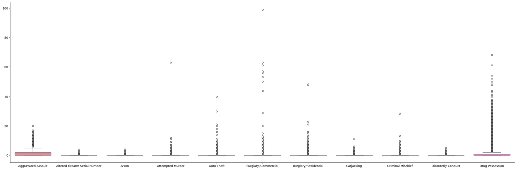

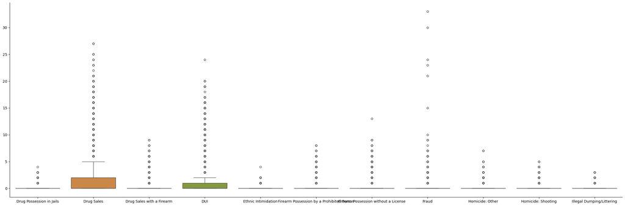

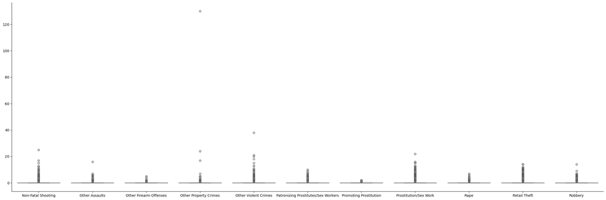

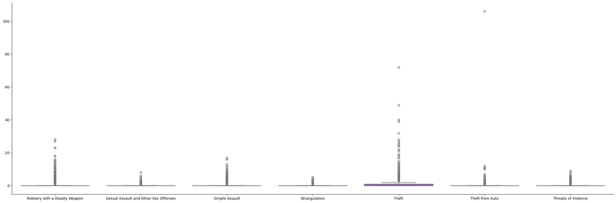

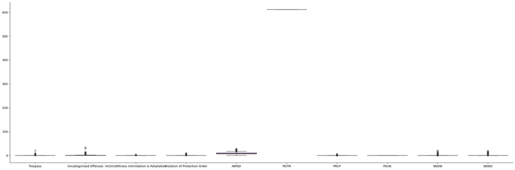

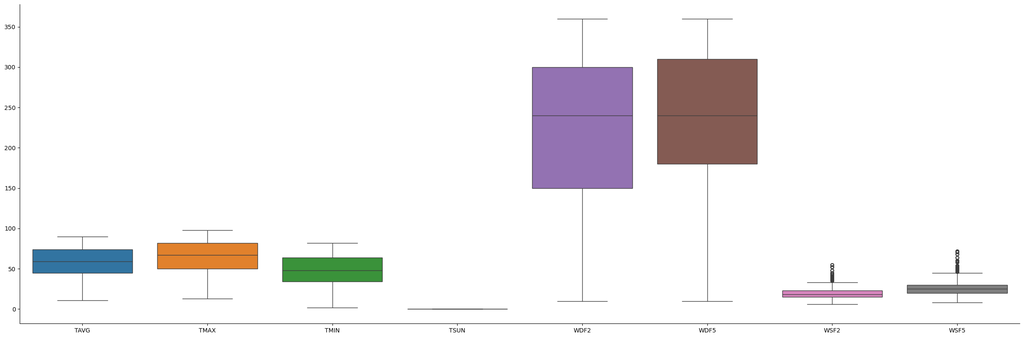

```python
sns.catplot(data=bails[columns[:11]], kind="box", height=8, aspect=3)
sns.catplot(data=bails[columns[11:22]], kind="box", height=8, aspect=3)
sns.catplot(data=bails[columns[22:33]], kind="box", height=8, aspect=3)
sns.catplot(data=bails[columns[33:40]], kind="box", height=8, aspect=3)
sns.catplot(data=bails[columns[40:-8]], kind="box", height=8, aspect=3)
sns.catplot(data=bails[columns[-8:]], kind="box", height=8, aspect=3)
```

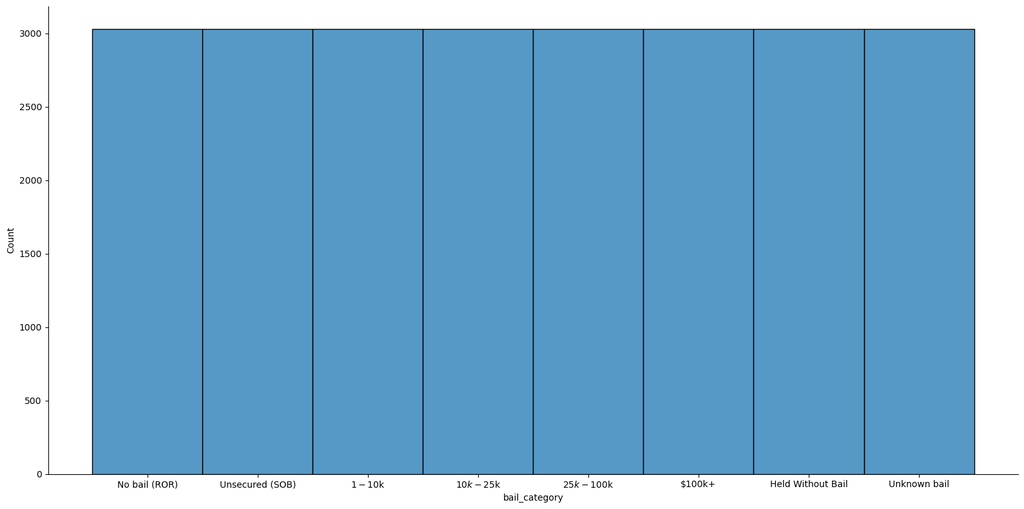

```python
sns.displot(bails['bail_category'], height = 8, aspect = 2)
```

While the graph above is pretty boring, it would make sense that every day has each category reported. This deeply boring graph is both reassuring that the dataset has no NaN, but also raises questions about whether the missing values are just filled with 0s by the city.

**Looking at correlations**, I want to see if Burglary/Commercial relates to Burglary/Residential, Drug Possession to Drug Possession in Jails, and if Drug Sales correlates to DUI. I'll start off this $\textit{expose}$ by visualizing these relations.

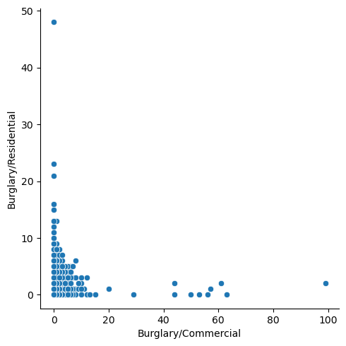

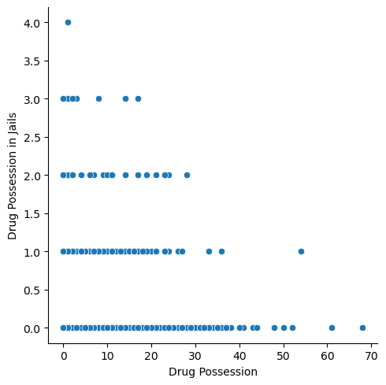

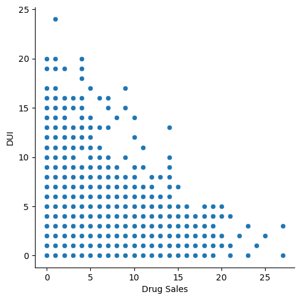

```python
sns.relplot(data=bails, x='Burglary/Commercial', y='Burglary/Residential')
sns.relplot(data=bails, x='Drug Possession', y='Drug Possession in Jails')
sns.relplot(data=bails, x='Drug Sales', y='DUI')
```

And I'll also print out the numerical values for the correlations in both their pearson and spearman beauty.

```python
print(bails[['Burglary/Commercial', 'Burglary/Residential']].corr())
print(bails[['Drug Possession', 'Drug Possession in Jails']].corr())
print(bails[['Drug Sales', 'DUI']].corr())
```

```
                      Burglary/Commercial  Burglary/Residential
Burglary/Commercial              1.000000              0.072795
Burglary/Residential             0.072795              1.000000
                          Drug Possession  Drug Possession in Jails
Drug Possession                   1.00000                   0.06956
Drug Possession in Jails          0.06956                   1.00000
            Drug Sales       DUI
Drug Sales    1.000000  0.165854
DUI           0.165854  1.000000
```

```python
print(bails[['Burglary/Commercial', 'Burglary/Residential']].corr("spearman"))
print(bails[['Drug Possession', 'Drug Possession in Jails']].corr('spearman'))
print(bails[['Drug Sales', 'DUI']].corr('spearman'))
```

```
                      Burglary/Commercial  Burglary/Residential
Burglary/Commercial              1.000000              0.203521
Burglary/Residential             0.203521              1.000000
                          Drug Possession  Drug Possession in Jails
Drug Possession                  1.000000                  0.097723
Drug Possession in Jails         0.097723                  1.000000
            Drug Sales       DUI
Drug Sales    1.000000  0.261287
DUI           0.261287  1.000000
```

Just to make this even more visual, I'll pull out the columns of interest and make a heatmap and be sure to set the color scheme to 'coolwarm'

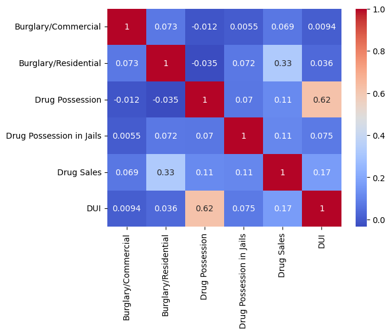

```python
columns = ['Burglary/Commercial', 'Burglary/Residential', 'Drug Possession', 'Drug Possession in Jails', 'Drug Sales', 'DUI']
C = bails[columns].corr()
sns.heatmap(C, annot=True, cmap="coolwarm")
```

It makes sense that the drug posession would correlate with the DUI (and this is a pretty decent correlation of 0.6) since a person being charger for a DUI could very well also be charged with Drug Posession

# Discussion

Can data about the max temperature on a day, the max 2 minute wind speed, percent of possible sunshine, and snowfall predict what proportion of aggrivated assault bails will be in the 1-10k category? (ie. does bad weather correlate to judges setting higher or lower bails?)

Can the time of year and number of bails posted for Drug Possession, DUI, and Drug Sales with a Firearm predict the number of bails posted for Drug Sales?